# United States Delayed Flights Dataset Visualisation and Exploration

## by (Ivan Babkin)

# Contents

## Dataset and Features of Interest Overview

## Total minutes delay distribution visualisation

## Relationship between Total minutes delay and Numeric Variables

## Relationship between Total minutes delay and Categorical Variables

### Dataset overview

There are 177,483 entries in the dataset. Each entry records flights of a specified airline to a specified airport during a specified month and year. Each entry provides the breakdown of causes of delayed flights in terms of the total number of flights and total delayed minutes. Excluding destination, carrier and airport names columns, which are categorical variables and are stored as strings, all other columns contain numeric values and are stored as floats.

### Main features of interest

Since the causes of delays are already clearly stated in the dataset, I am most interested in finding out what influences the total delayed minutes for every entry.

I believe that the main variables influencing the delayed minutes are the number of flights arriving and the number of delayed flights in every entry. Thus, I believe that these variables will be highly correlated with each other. Furthermore, I also believe that the categorical variables of year, month, destination, and the carrier will also affect the total delayed minutes.

Therefore, the following predictor variables will be visualised:

**Numerical variables**

1. Total number of flights arriving
2. Number of delayed flights

**Categorical variables**

1. Year
2. Month
3. Destination
4. Carrier

# Total minutes delay distribution visualisation

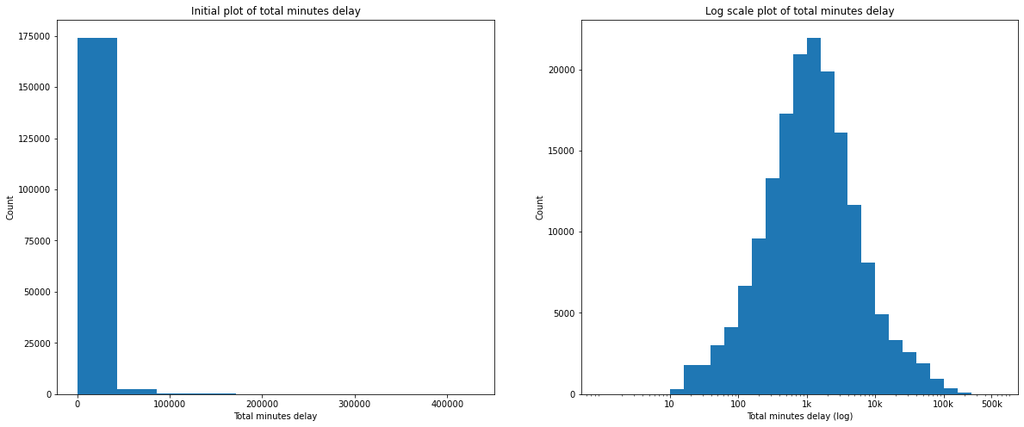

Total minutes delay data is significantly skewed to the right, and therefore a log scale was used to properly visualise the data. Total minutes delay in the dataset takes on a very large range of values, where the vast majority of the entries are distributed between 0 and 100k total minutes delay. Most entries have less than 10k total delayed minutes; however, some entries have even more than 400k total delayed minutes. Interestingly, despite the mentioned skewness, the log scale graph shows that the data resembles a normal distribution.

# Relationship between Total minutes delay and Numeric Variables

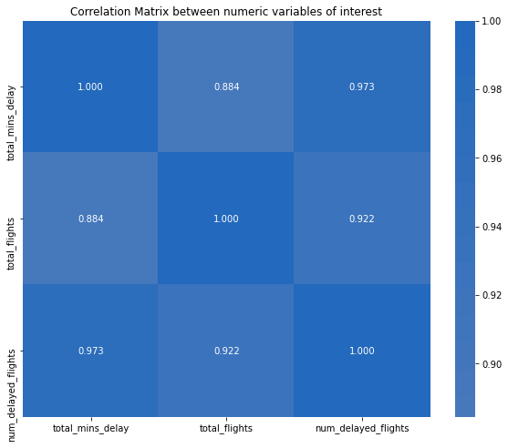

As can be seen from the correlation matrix, all chosen numeric variables are highly correlated with each other, where the lowest correlation between the three variables is 0.884. As previously mentioned, this is to be expected as the total minutes delay is likely to depend on how many flights are delayed. Similarly, the number of flights delayed is likely to depend on how many flights there were originally.

# Relationship between Total minutes delay and Categorical Variables

# Relationship between Total minutes and Year

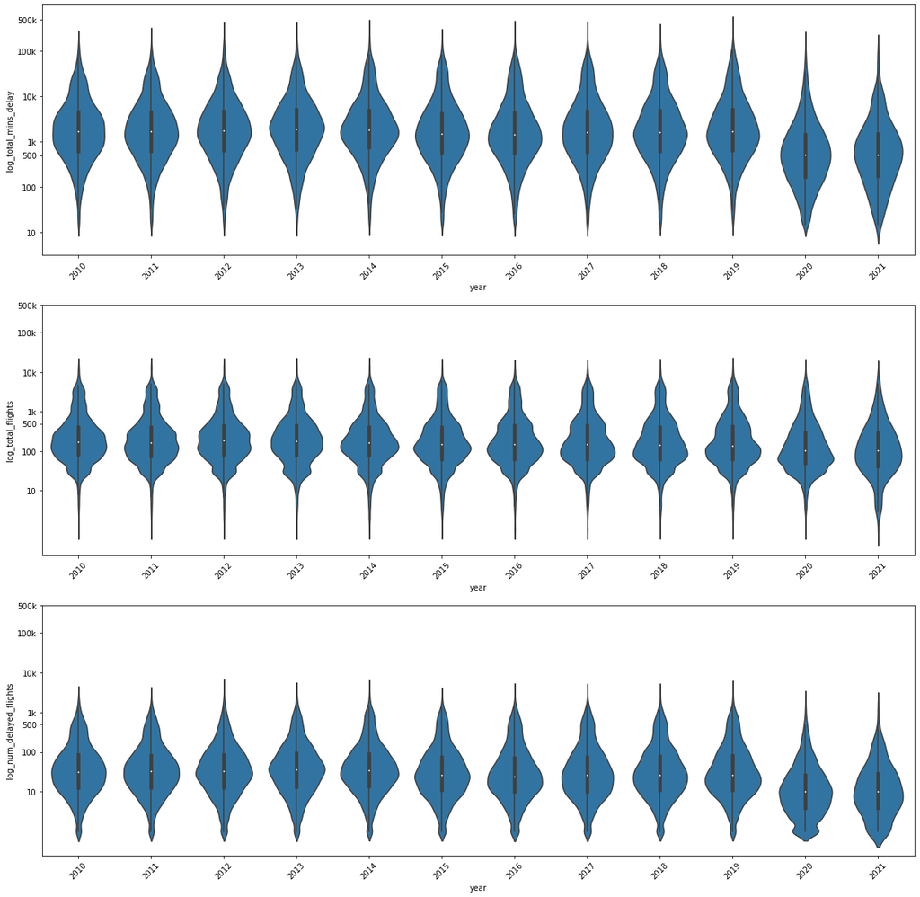

# Relationship between Total minutes and Month

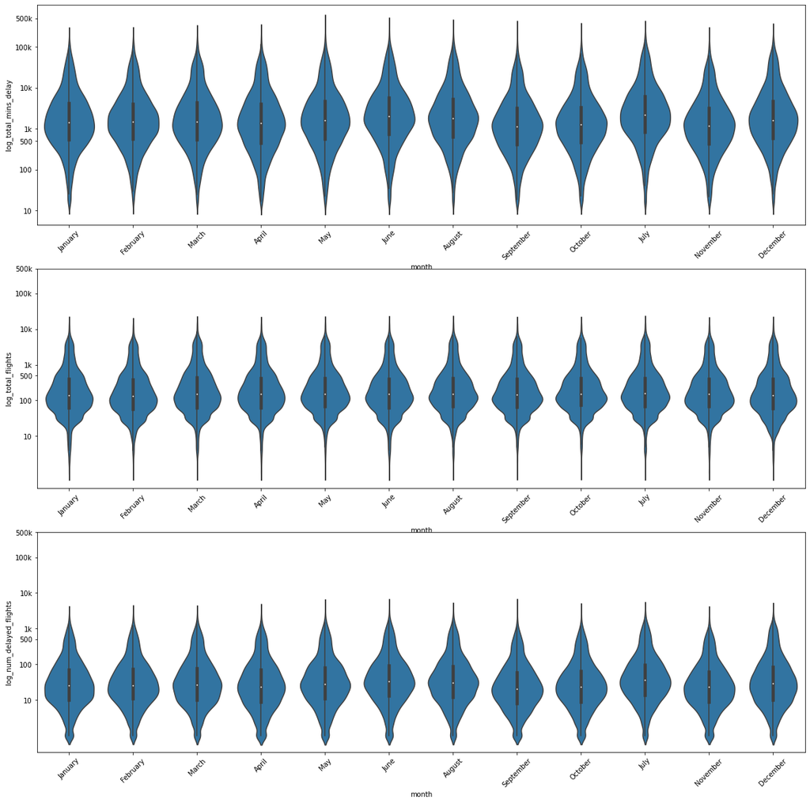

# Relationship between Total minutes and Top 10 Destinations

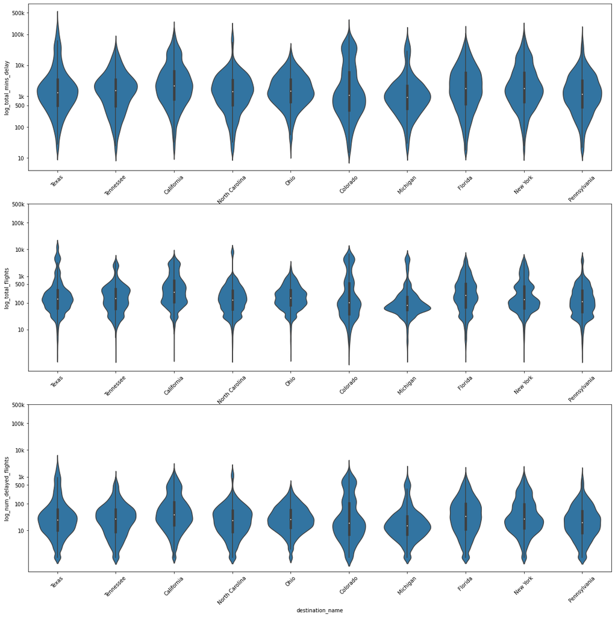

The violin plots show that the total minutes delay have very varying distributions among the top 10 destinations. While the median seems to be roughly similar, the shape of the violin plot is vastly different from one destination to the next. The same could be said for the second and the third violin plots showing that total flights and the number of delayed flights is also vastly different among the top destinations.

# Relationship between Total minutes and Top 10 Carriers

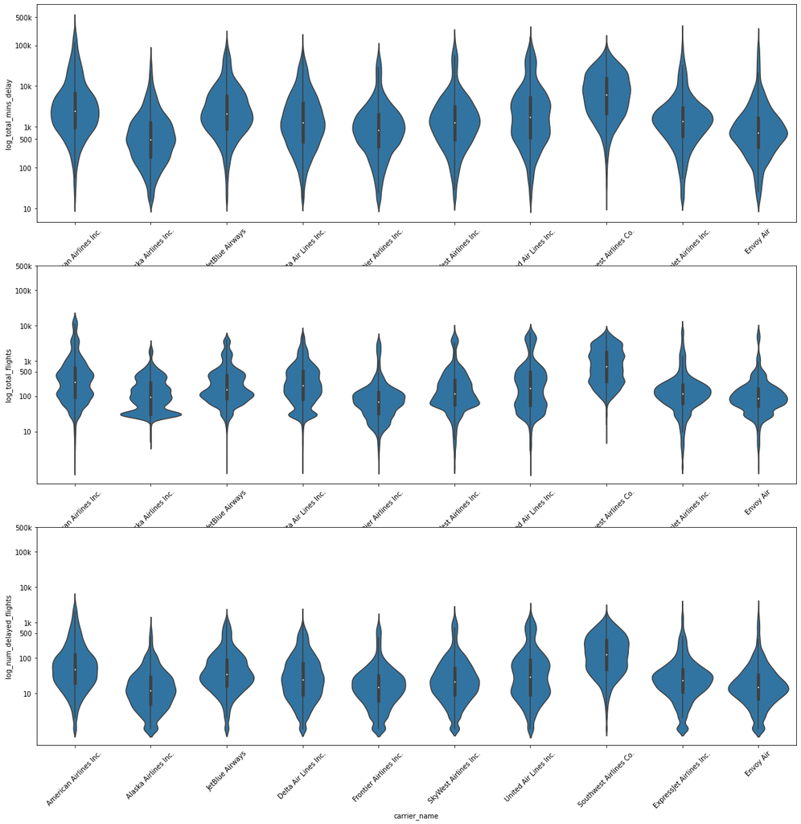

Similar to the total mins delay distribution among the top 10 destinations, the distribution of total mins delay among the top 10 carriers does not follow a pattern. However, unlike the plots for the top 10 destinations, there is a visibly significant difference in the total minutes delay median and quartiles for the top 10 carriers. The same could also be said for the violin plots for total flights and the number of delayed flights.